# Midterm

Ruowen Wang

10/8/2020

### Introduction:

1. Question: I am trying to find the association between the social distance index with the incidence rate of COVID-19. To check whether keeping social distance is an effective way to slow down the spread of COVID-19.
2. Explanation: The social distance index is an integer from 0~100 that represents the extent residents and visitors are practicing social distancing. “0” indicates no social distancing is observed in the community, while “100” indicates all residents are staying at home and no visitors are entering the county.Calculated by MTI.

### Methods:

1. Data source: Social distance index: https://dataverse.harvard.edu/dataset.xhtml?persistentId=doi:10.7910/DVN/ZAKKCE Total US confirmed cases: https://dataverse.harvard.edu/dataset.xhtml?persistentId=doi:10.7910/DVN/HIDLTK
2. I find out the number of columns and rows of both data set. Then I delete the extra columns and rows, focus on the same period.

### Preliminary Results:

Please see Step 4.

### Code:

```r
library(data.table)
library(leaflet)
library(tidyverse)
```

```r
library(dplyr)
library(ggplot2)
library(knitr)
library(usmap)
library(scales)
library(RColorBrewer)
```

### Step1: Read in data.

```r
sdi <- data.table::fread("/Users/christina/Desktop/Social distancing index_ST.csv")
totcases <- data.table::fread("/Users/christina/Desktop/us_state_confirmed_case.csv")
```

### Step2: Check the dimensions, headers, footers, and the trend of the social distance.

- For the sake of presentation friendliness, we only show 8 lines for the first and last part of the data.
- For the trends plot, I only show the four states for 50 days. They have very similar fluctuating trends in social distancing.
- There are 51 rows and 275 columns in the social distance index data set.
- The date is updated from Jan/01/2020 to Sep/28/2020.

```r
dim(sdi)
```

```
## [1]  51 275
```

```r
head(sdi[,1:8])
```

```
##    V1 STATE       NAME 01/01/2020 01/02/2020 01/03/2020 01/04/2020 01/05/2020
## 1:  0     1    Alabama         52         27         17         28         41
## 2:  1     2     Alaska         54         23         20         37         47
## 3:  2     4    Arizona         46         19         16         27         39
## 4:  3     5   Arkansas         49         23         14         28         40
## 5:  4     6 California         50         22         18         31         43
## 6:  5     8   Colorado         49         16         15         25         40
```

```r
tail(sdi[,268:275])
```

```
##    09/21/2020 09/22/2020 09/23/2020 09/24/2020 09/25/2020 09/26/2020 09/27/2020
## 1:         22         50         45         44         36         25         28
## 2:         32         31         26         25         24         29         34
## 3:         32         37         35         33         30         31         36
## 4:         20         32         28         26         21         25         28
## 5:         22         20         18         19         17         25         29
## 6:         20         30         26         26         23         24         30
##    09/28/2020
## 1:         25
## 2:         33
## 3:         33
## 4:         21
## 5:         27
## 6:         20
```

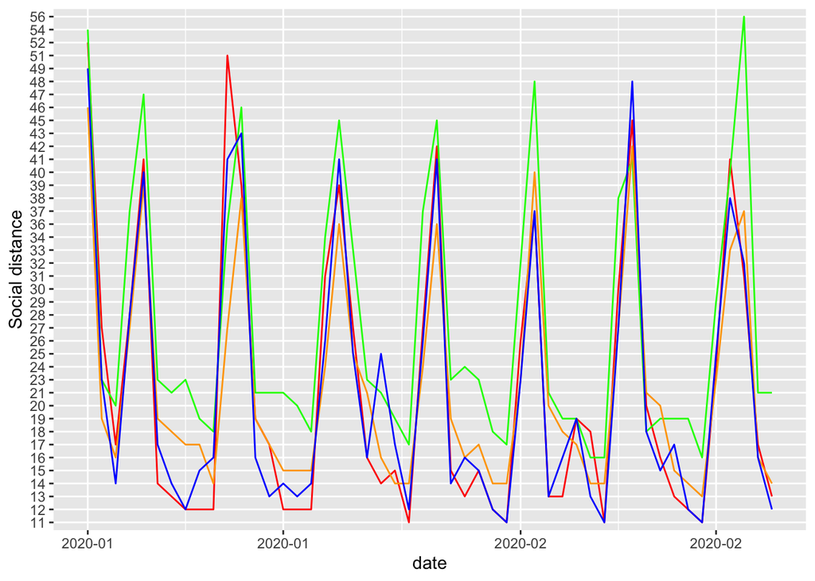

```r
library(ggplot2)
library(scales)
data1 = t(as.matrix(sdi[,3:275]))
date = colnames(sdi)[4:275]
rownames(data1) <- NULL
colnames(data1) = data1[1,]
data1 = as.data.frame(data1)[2:273,]
data1$date = as.Date(date,format ("%m/%d/%Y"))
data1 = data1[1:50,]
ggplot(data1, aes(x=date)) + geom_line(aes(y=Alabama,group = 1),color="red")+ geom_line(aes(y=Alaska,group = 1),color="green")+geom_line(aes(y=Arizona,group = 1),color="orange")+geom_line(aes(y=Arkansas,group = 1),color="blue") +scale_y_discrete('Social distance')+scale_x_date(labels=date_format("%Y-%m"))
```

- For the sake of presentation friendliness, I only show 15 lines for the first and the last part.
- For the total US confirmed cases, I only show the same four states above for 10 days. We also can see the same trend in these four countries, but Alaska have little confirmed case.
- There are 51 rows and 272 columns in the total US confirmed cases data set.
- The date is updated from Jan/21/2020 to Oct/06/2020.

```r
dim(totcases)
```

```
## [1]  51 272
```

```r
head(totcases[,1:15])
```

```
##    fips       NAME    POP70   HHD70    POP80   HHD80    POP90    HHD90    POP00
## 1:    1    Alabama  3434507 1031615  3886040 1340563  4040576  1506778  4447059
## 2:    2     Alaska   225211   61547   393155  130004   549808   188909   626932
## 3:    4    Arizona  1768275  538809  2705322  953006  3663266  1368775  5130674
## 4:    5   Arkansas  1901082  608500  2253450  805730  2350107   891049  2673393
## 5:    6 California 19838084 6570174 23575384 8624938 29724503 10377409 33871650
## 6:    8   Colorado  2181196  684818  2828761 1042987  3278284  1276564  4284074
##       HHD00    POP10    HHD10 2020-01-21 2020-01-22 2020-01-23
## 1:  1737086  4779736  1883791          0          0          0
## 2:   221599   710231   258058          0          0          0
## 3:  1901349  6392017  2380990          0          0          0
## 4:  1042696  2915918  1147084          0          0          0
## 5: 11502847 37253956 12577498          0          0          0
## 6:  1652051  5029196  1972868          0          0          0
```

```r
tail(totcases[,258:272])
```

```
##    2020-09-22 2020-09-23 2020-09-24 2020-09-25 2020-09-26 2020-09-27 2020-09-28
## 1:       1721       1722       1724       1731       1739       1742       1745
## 2:     142010     142590     143492     144433     145408     146144     146593
## 3:      87233      88042      88597      89149      89514      89822      90596
## 4:      14384      14504      14706      14953      15158      15348      15512
## 5:     110393     112276     114743     117355     120249     122498     124320
## 6:       5016       5169       5305       5420       5465       5633       5754
##    2020-09-29 2020-09-30 2020-10-01 2020-10-02 2020-10-03 2020-10-04 2020-10-05
## 1:       1749       1752       1755       1768       1778       1785       1817
## 2:     147516     148271     148721     149687     150803     151870     152557
## 3:      91011      91560      92166      92727      93160      93527      94202
## 4:      15692      15848      16024      16307      16468      16628      16742
## 5:     126744     129172     132176     134996     138018     139941     141780
## 6:       5821       5948       6083       6214       6365       6504       6629
##    2020-10-06
## 1:       1821
## 2:     153182
## 3:      94694
## 4:      16936
## 5:     143886
## 6:       6770
```